# InVivoStat Logistic Regression Analysis

## Response and covariate

The Response1a response is currently being analysed by the Logistic Regression Analysis module, with Covariate1 fitted as a covariate.The covariate has been square root transformed prior to analysis.

## Analysis of deviance table

| Effect | Degrees of freedom | Chi-square | p-value |
| --- | --- | --- | --- |
| (Intercept) | 1 | 10.045 | 0.0015 |
| Covariate1 | 1 | 0.309 | 0.5780 |
| Cont1 | 1 | 25.093 | < 0.0001 |
| Cont2 | 1 | 0.295 | 0.5871 |
| Cont3 | 1 | 0.110 | 0.7405 |

Comment: Analysis of deviance table calculated using a Type III model fit, see Armitage et al. (2001).

Conclusion: There is a statistically significant overall difference between the levels of (Intercept), Cont1.

## Plot of model predictions

This option is only available if the model contains a single continuous factor.

## Odds ratio

| Parameter | Odds ratio | Lower 95% CI | Upper 95% CI |
| --- | --- | --- | --- |
| Cont1 | 0.17 | 0.07 | 0.30 |
| Cont2 | 0.85 | 0.46 | 1.60 |
| Cont3 | 1.15 | 0.52 | 2.78 |

Note: Confidence intervals are based on the profiled log-likelihood function.

To interpret these results: For a one-unit increase in the parameter, the odds ratio (given as a fold-change) indicates the corresponding increase/decrease in the probability that the response gives a 'positive result'.

## Model prediction assessment

|  | Predicted response = -1 | Predicted response = 4 |
| --- | --- | --- |
| Observed level = -1 | 43 | 9 |
| Observed level = 4 | 8 | 62 |

The model correctly classifies the responses 86.07% of the time.

## Model predictions

The model predictions correspond to the predicted probability of obtaining a positive result (i.e. response equals -1)

| Observation number | Response1a | Cont1 | Cont2 | Cont3 | Covariate1 | Predictions |
| --- | --- | --- | --- | --- | --- | --- |
| 1 | -1 | 1 | 1 | 1 | 0.41 | 0.997 |
| 2 | -1 | 1 | 1 | 3 | 0.28 | 0.998 |
| 3 | -1 | 1 | 4 | 2 | 0.80 | 0.993 |
| 4 | -1 | 1 | 4 | 3 | 0.60 | 0.995 |
| 5 | -1 | 1 | 1 | 1 | 0.53 | 0.996 |
| 6 | -1 | 1 | 1 | 3 | 0.66 | 0.997 |
| 7 | -1 | 1 | 4 | 2 | 0.32 | 0.995 |
| 8 | -1 | 1 | 4 | 3 | 0.40 | 0.996 |
| 9 | -1 | 1 | 1 | 3 | 0.28 | 0.998 |
| 10 | -1 | 1 | 4 | 2 | 0.80 | 0.993 |
| 11 | -1 | 1 | 4 | 3 | 0.60 | 0.995 |
| 12 | -1 | 1 | 1 | 1 | 0.53 | 0.996 |
| 13 | -1 | 1 | 1 | 3 | 0.66 | 0.997 |
| 14 | -1 | 1 | 4 | 2 | 0.32 | 0.995 |
| 15 | -1 | 1 | 4 | 3 | 0.40 | 0.996 |
| 16 | -1 | 2 | 2 | 2 | 0.75 | 0.972 |
| 17 | -1 | 2 | 2 | 1 | 0.73 | 0.968 |
| 18 | -1 | 2 | 1 | 3 | 0.80 | 0.978 |
| 19 | -1 | 2 | 5 | 4 | 0.59 | 0.970 |
| 20 | -1 | 2 | 2 | 2 | 0.90 | 0.967 |
| 21 | -1 | 2 | 2 | 1 | 0.67 | 0.970 |
| 22 | -1 | 2 | 1 | 3 | 0.47 | 0.984 |
| 23 | -1 | 2 | 5 | 4 | 0.62 | 0.969 |
| 24 | -1 | 2 | 2 | 1 | 0.73 | 0.968 |
| 25 | -1 | 2 | 1 | 3 | 0.80 | 0.978 |
| 26 | -1 | 2 | 5 | 4 | 0.59 | 0.970 |
| 27 | -1 | 2 | 2 | 2 | 0.90 | 0.967 |
| 28 | -1 | 2 | 2 | 1 | 0.67 | 0.970 |
| 29 | -1 | 2 | 1 | 3 | 0.47 | 0.984 |
| 30 | -1 | 2 | 5 | 4 | 0.62 | 0.969 |

[output cut: 92 more lines]

## McFadden's pseudo R-sq

|  | R-sq value | Degrees of freedom |
| --- | --- | --- |
| Test result | 0.6611 | 5 |

McFadden's pseudo R-sq (McFadden, 1974) is defined as 1-[ln(LM)/ln(L0)], where ln(LM) is the log likelihood value for the fitted model and ln(L0) is the log likelihood for the null model with only an intercept as a predictor. The measure ranges from 0 to 1, with values closer to zero indicating that the model has no predictive power.

## Receiver operating characteristic (ROC) curve

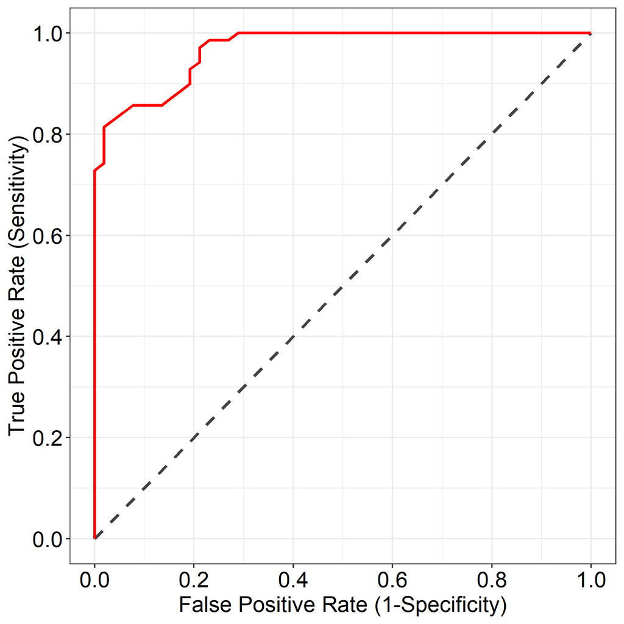

The ROC curve (Receiver Operating Characteristic) is a way to assess how good the model is at identifying (i) true positive results (or successes), measured by 'sensitivity' - the probability of predicting a true positive/success and (ii) true negative results (or failures), measured by 1-'specificity' - the probability of predicting a false positive/success. The best decision rule is high on sensitivity and low on 1-specificity. The ROC curve illustrates this.

A model that predicts no better than chance will have an ROC curve that closely follows the diagonal dotted line. The further the curve is above the diagonal line, the better the model is at discriminating between positives and negatives.

The ROC curve can also be summarised by the area under curve (AUC). The closer the AUC is to 1, the better the model is at discriminating between positives and negatives. In this case the AUC of the curve is 0.9679.

## Analysis description

The data were analysed using a 3-way logistic regression approach, with Cont1, Cont2 and Cont3 as the continuous factors and Covariate1 as the covariate. The covariate has been square root transformed prior to analysis. A positive result has been defined as -1.

## References

When referring to InVivoStat, please cite 'InVivoStat, version 5.2.0'.

McFadden, D. (1974) Conditional Logit Analysis of Qualitative Choice Behavior. In: Zarembka, P., Ed., Frontiers in Econometrics, Academic Press, 105-142.